# Homework on SFPD Data

Danning Peng, Daniel Chia

4/24/2017

This homework requires you to analyze crime data from San Francisco, using exploratory data analysis (EDA). This is a **group** homework.

Q1: Read in the data using the **fread()** function in R. How many rows and columns of data do you have? The file is “SFPD_Incidents_from_January_2003.csv”.

```r
library(data.table)
crime_data = fread("~/Downloads/SFPD_Incidents_from_January_2003.csv")
```

```
##
Read 0.0% of 2047932 rows
Read 27.3% of 2047932 rows
Read 52.2% of 2047932 rows
Read 77.6% of 2047932 rows
Read 2047932 rows and 13 (of 13) columns from 0.391 GB file in 00:00:07
```

```r
print(dim(crime_data))
```

```
## [1] 2047932      13
```

Q2: How many different types of crime categories are there? Print them out.

```r
print(unique(crime_data$Category))
```

```
##  [1] "NON-CRIMINAL"                "ROBBERY"
##  [3] "ASSAULT"                     "SECONDARY CODES"
##  [5] "VANDALISM"                   "BURGLARY"
##  [7] "LARCENY/THEFT"               "DRUG/NARCOTIC"
##  [9] "WARRANTS"                    "VEHICLE THEFT"
## [11] "OTHER OFFENSES"              "WEAPON LAWS"
## [13] "ARSON"                       "MISSING PERSON"
## [15] "DRIVING UNDER THE INFLUENCE" "SUSPICIOUS OCC"
## [17] "RECOVERED VEHICLE"           "DRUNKENNESS"
## [19] "TRESPASS"                    "FRAUD"
## [21] "DISORDERLY CONDUCT"          "SEX OFFENSES, FORCIBLE"
## [23] "FORGERY/COUNTERFEITING"      "KIDNAPPING"
## [25] "EMBEZZLEMENT"                "STOLEN PROPERTY"
## [27] "LIQUOR LAWS"                 "FAMILY OFFENSES"
## [29] "LOITERING"                   "BAD CHECKS"
## [31] "TREA"                        "GAMBLING"
## [33] "RUNAWAY"                     "BRIBERY"
## [35] "PROSTITUTION"                "PORNOGRAPHY/OBSCENE MAT"
## [37] "SEX OFFENSES, NON FORCIBLE"  "SUICIDE"
## [39] "EXTORTION"
```

Q3: Plot the total incidence of crime over time by year using the **ggplot** package. Label the axes properly and make sure the plot is complete and looks good.

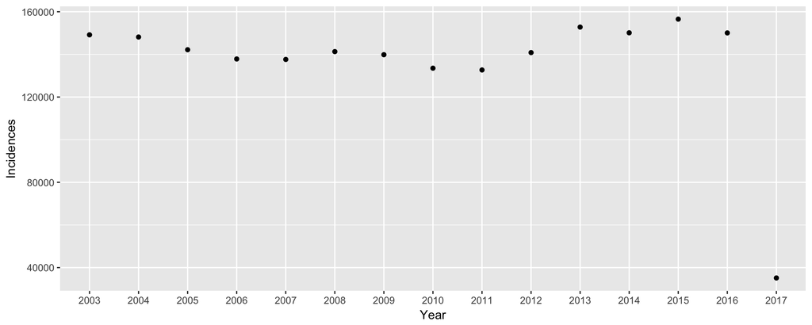

```r
year1 <- crime_data$Date
year <- sapply(year1, function(x) strsplit(x, "/")[[1]][3])
df<-data.frame(x=1, y=year)
DT <- data.table(df)
DT <- DT[, sum(x), by = y]
DT <- DT[order(y)]
library(ggplot2)
qplot(data=DT, x=y, y=V1, xlab="Year", ylab="Incidences")
```

Q4: Create a table to show the frequency of all crimes over time. This data frame should have one column per crime. Be careful to handle missing values as all crimes may not occur every year. Print out the top of this data frame.

```r
crime <- crime_data$Category
df2<-data.frame(x = crime, y = 1)
DT2 <- data.table(df2)
DT2 <- DT2[, sum(y), by = x]
colnames(DT2) <- c("Crime", "Number")
DT2 <- DT2[order(Number, decreasing=TRUE)]
head(DT2, 10)
```

```
##              Crime Number
##  1:  LARCENY/THEFT 429183
##  2: OTHER OFFENSES 289803
##  3:   NON-CRIMINAL 219532
##  4:        ASSAULT 179438
##  5:  VEHICLE THEFT 120855
##  6:  DRUG/NARCOTIC 115679
##  7:      VANDALISM 105776
##  8:       WARRANTS  95707
##  9:       BURGLARY  84997
## 10: SUSPICIOUS OCC  74042
```

Q5: Compute the correlations of all crimes and report top 10 pairs of crimes that are most correlated.

```r
df3 <- data.frame(x = crime, y = year, z = 1)
DT3 <- data.table(df3)
DT3 <- DT3[, sum(z), by = .(x, y)]
colnames(DT3) <- c("Crime", "Year", "Number")
DT3 <- DT3[order(Crime, Year)]
library(reshape2)
DT3 <- acast(DT3, Year~Crime, value.var="Number")
res <- cor(DT3)
res <- round(res, 2)
crimes <- sort(unique(crime_data$Category))
```

[output not shown]

Q6: Plot all the crimes by year to see how they evolve. Choose any plot type you think will be the best visualization of the data. Make sure this is something readable and not a mess!

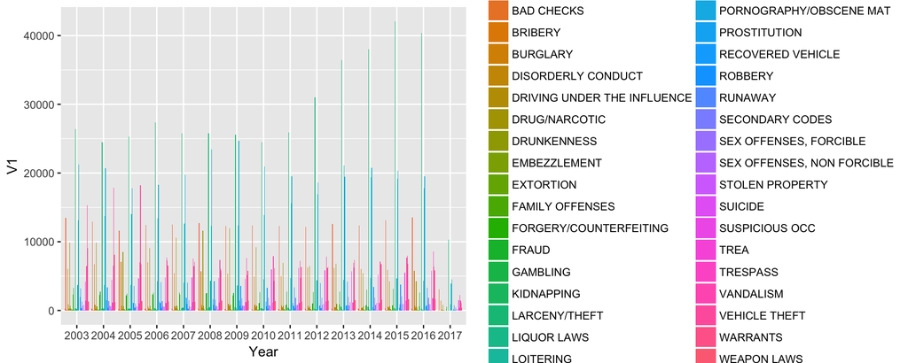

```r
library(ggplot2)
crime <- crime_data$Category
year1 <- crime_data$Date
year <- sapply(year1, function(x) strsplit(x, "/")[[1]][3])
df2<-data.frame(x = crime, y = year, z = 1)
DT2 <- data.table(df2)
colnames(DT2) <- c("Category", "Year", "Number")
data <- DT2
data <- data[, sum(Number), by = .(Category, Year)]
data <- data[order(Category, Year)]
ggplot(data, aes(fill=Category, y=V1, x=Year)) +
    geom_bar(position="dodge", stat="identity")
```

Q7: Create a pie chart of all crimes (aggregate across all years).

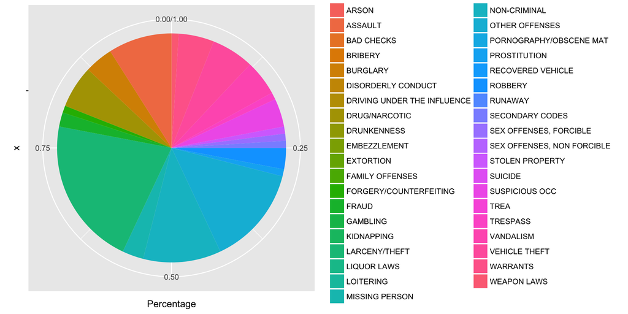

```r
library(ggplot2)
crime <- crime_data$Category
df2<-data.frame(x = crime, y = 1)
DT2 <- data.table(df2)
DT2 <- DT2[, sum(y), by = x]
total = sum(DT2$V1)
df3 <- data.frame(DT2$x, round(DT2$V1/total,2))
DT3 <- data.table(df3)
colnames(DT3) <- c("Crime", "Percentage")
ggplot(DT3, aes(x="", y=Percentage, fill=Crime))+ geom_bar(width = 1, stat = "identity") + coord_polar("y", start=0)
```

Q8: Plot the total crimes by lattitude and longitude, for all combinations of police district and crime category, using a scatter plot. Make the scatter plot interactive using the **rbokeh** package.

```r
library(rbokeh)
p <- gmap(lat = 37.78, lng = -122.42, zoom = 13) %>% ly_points(X, Y, data = crime_data, hover = c(Category, PdDistrict), col = 'red') %>% x_axis(visible = FALSE) %>% y_axis(visible = FALSE)
```

(The satallite map can be successfuly displayed after running this code block, but my PC(4GB Memory) is too slow to load it, resulting the breakdown of RStudio, thus please try the code on other devices! Also the map I generated is filled with red dots..but due to the breakdown issue, I was not able to modify the code and see if anything can change. Look forward to see the correct code!)

Q9: Using annual counts, how much of DRUG/NARCOTIC offences can you explain using the number of LIQOUR LAWS, PROSTITUTION, and WEAPON LAWS violations?

```r
library(data.table)
library(ggplot2)
crime_data = fread("~/Downloads/SFPD_Incidents_from_January_2003.csv")
```

```
##
Read 0.0% of 2047932 rows
Read 21.0% of 2047932 rows
Read 45.4% of 2047932 rows
Read 70.8% of 2047932 rows
Read 92.3% of 2047932 rows
Read 2047932 rows and 13 (of 13) columns from 0.391 GB file in 00:00:07
```

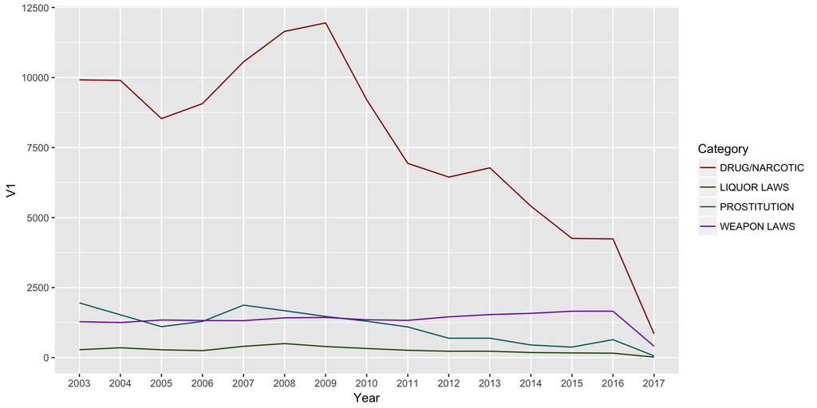

```r
crime <- crime_data$Category
year1 <- crime_data$Date
year <- sapply(year1, function(x) strsplit(x, "/")[[1]][3])
df2<-data.frame(x = crime, y = year, z = 1)
DT2 <- data.table(df2)
colnames(DT2) <- c("Category", "Year", "Number")
data <- subset(DT2, Category == 'DRUG/NARCOTIC' | Category == 'LIQUOR LAWS' | Category == 'PROSTITUTION' | Category == 'WEAPON LAWS')
data <- data[, sum(Number), by = .(Category, Year)]
data <- data[order(Category, Year)]
ggplot(data, aes(y=V1, x=Year, group=Category, shape=Category, colour=Category)) + geom_line() + scale_colour_hue(name="Category", l=30)  + scale_linetype_discrete(name="Category")
```

From the line chart above we can see that, the incidences of DRUG/NARCOTIC are much more popular the other three types of crimes. Incidences breaching WEAPON LAWS and LIQUOR LAWS seems to be parallel to each other. Also, the increases of PROSTITUTION and LIQUOR LAWS breaching seem to lead the increases of DRUG/NARCOTIC breaching, or DRUG/NARCOTIC breaching is leading or occuring together with PROSTITUTION and LIQUOR LAWS.

Q10: How would you show in one picture, which crimes occur together the most?

```r
Day <- crime_data$Date
Time <- crime_data$Time
Place <- crime_data$Address
df2 <- data.frame(x = crime, y = Day, w = Time, u = Place, z = 1)
DT2 <- data.table(df2)
colnames(DT2) <- c("Category", "Date", "Time", "Address", "Number")
DT2 <- DT2[, sum(Number), by = .(Date,Time,Address,Category)]
DT2 <- DT2[order(Date,Time,Address)]
DT3 <- subset(DT2, V1 > 1)
```

(It seems like this question needs Bayes Model to reach the solution, but I have too limited knowledge to get it done, I can only generate the code above. Thus look forward to the correct solution as well!)